# Manual classification of tumor cells

Ally Hawkins

2024-06-03

## Introduction

This notebook looks at expression of marker genes for tumor cells in a Ewing sarcoma sample, SCPCS000490. We then see if we can use expression of marker genes to manually classify tumor and normal cells. The main goal of this notebook is only to identify tumor cells, identification and labeling of the other cells is a separate question that we do not answer here.

## Setup

```r
suppressPackageStartupMessages({
  # load required packages
  library(SingleCellExperiment)
  library(ggplot2)
})

# Set default ggplot theme
theme_set(
  theme_bw()
)
```

```r
# The base path for the OpenScPCA repository, found by its (hidden) .git directory
repository_base <- rprojroot::find_root(rprojroot::is_git_root)

# The current data directory, found within the repository base directory
data_dir <- file.path(repository_base, "data", "2024-05-01")
sample_dir <- file.path(data_dir, "SCPCP000015", params$sample_id)

# The path to this module
module_base <- file.path(repository_base, "analyses", "cell-type-ewings")
```

```r
# source in helper functions: make_jaccard_matrix() and jaccard()
jaccard_functions <- file.path(module_base, "scripts", "utils", "jaccard-functions.R")
source(jaccard_functions)
```

```r
# Input files
sce_filename <- glue::glue("{params$library_id}_processed.rds")
sce_file <- file.path(sample_dir, sce_filename)

marker_genes <- file.path(module_base, "references", "tumor-marker-genes.tsv")

# output tumor/normal classifications
results_dir <- file.path(module_base, "results", "marker_gene_analysis")
fs::dir_create(results_dir)

classifications_filename <- glue::glue("{params$library_id}_tumor_normal_classifications.tsv")
output_classifications_file <- file.path(results_dir, classifications_filename)
```

```r
# read in processed sce
sce <- readr::read_rds(sce_file)

# read in marker genes table
marker_genes_df <- readr::read_tsv(marker_genes) |>
  # account for genes being from multiple sources
  dplyr::select(cell_type, ensembl_gene_id, gene_symbol) |>
  dplyr::distinct()
marker_genes <- marker_genes_df |>
  dplyr::filter(cell_type == "tumor") |>
  dplyr::pull(ensembl_gene_id)
```

## Analysis content

### Explore marker gene expression

The first thing we do here is just create a faceted UMAP showing the expression of each marker gene for tumor cells.

```r
# get the gene expression counts for all marker genes
marker_gene_exp <- logcounts(sce[marker_genes, ]) |>
  as.matrix() |>
  t() |>
  as.data.frame() |>
  tibble::rownames_to_column("barcodes")

# pull out the UMAP coordinates and make a data frame to use for plotting
umap_df <- sce |>
  scuttle::makePerCellDF(use.dimred = "UMAP") |>
  # replace UMAP.1 with UMAP1
  dplyr::rename_with(
        \(x) stringr::str_replace(x, "^UMAP\\.", "UMAP")
      ) |>
  # add in marker gene expression to dataframe
  dplyr::left_join(marker_gene_exp, by = "barcodes") |>
  # combine all genes into a single column for easy faceting
  tidyr::pivot_longer(
    cols = starts_with("ENSG"),
    names_to = "ensembl_gene_id",
    values_to = "gene_expression"
  ) |>
  # join with marker gene df to get gene symbols for plotting
  dplyr::left_join(marker_genes_df, by = c("ensembl_gene_id")) |>
  dplyr::select(barcodes, UMAP1, UMAP2, gene_symbol, ensembl_gene_id, gene_expression, cluster)
```

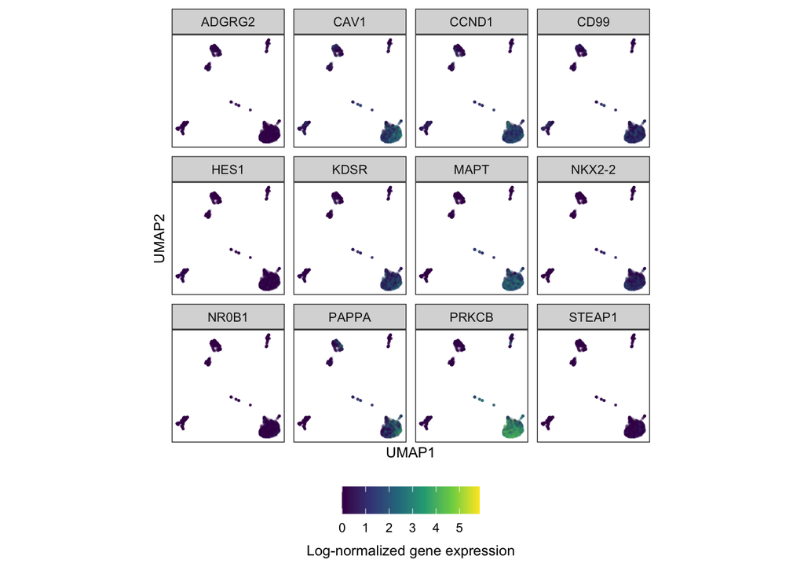

```r
# faceted umap showing a umap panel for each marker gene
ggplot(umap_df, aes(x = UMAP1, y = UMAP2, color = gene_expression)) +
    geom_point(alpha = 0.1, size = 0.2) +
    facet_wrap(vars(gene_symbol)) +
    scale_color_viridis_c() +
    labs(
      color = "Log-normalized gene expression"
    ) +
    # remove axis numbers and background grid
    scale_x_continuous(labels = NULL, breaks = NULL) +
    scale_y_continuous(labels = NULL, breaks = NULL) +
    theme(
      aspect.ratio = 1,
      legend.position = "bottom",
      axis.title = element_text(size = 9, color = "black"),
      strip.text = element_text(size = 8),
      legend.title = element_text(size = 9),
      legend.text = element_text(size = 8)
    ) +
    guides(colour = guide_colorbar(title.position = "bottom", title.hjust = 0.5))
```

Looking at this plot, there is definitely some variation in the expression of marker genes. It looks like the highest gene expression is seen in the larger group of cells on the bottom right of the UMAP.

We can also look at the distributions for each marker gene. I would expect to see some sort of bimodal distribution separating cells that do and do not have expression of the marker gene.

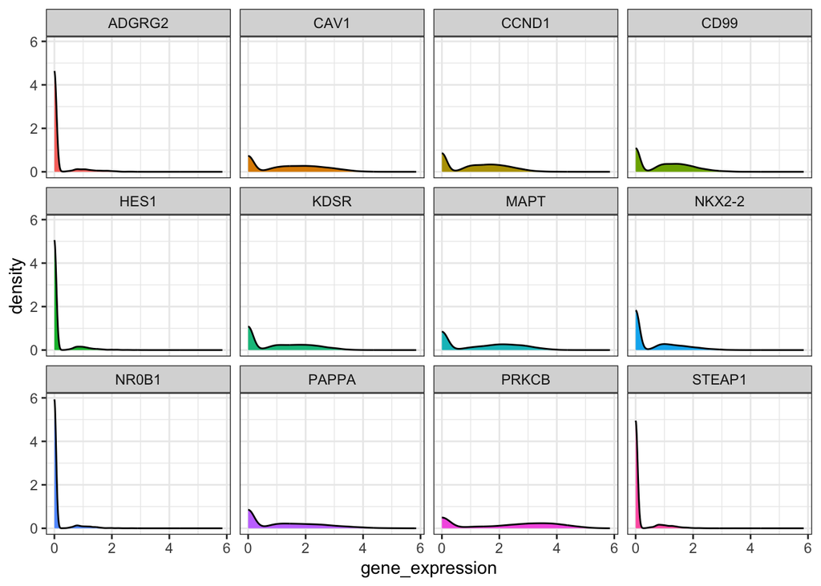

```r
ggplot(umap_df, aes(x = gene_expression, fill = gene_symbol)) +
  geom_density() +
  facet_wrap(vars(gene_symbol)) +
  theme(legend.position = "none")
```

Although we see some slight semblance of a bimodal distribution for most marker genes, it is hard to see and we cannot directly compare gene expression values across genes. This would make it hard to identify a cut off to categorize cells as expression or not expressing the marker gene.

Now we will transform each of the gene expression vectors by generating z-scores. Then we might be able to find a cut off we can use across samples for if marker genes are present in a cell or not.

```r
umap_df <- umap_df |>
  dplyr::group_by(gene_symbol) |>
  # get z-scores for each gene
  dplyr::mutate(transformed_gene_expression = scale(gene_expression)[, 1]) |>
  dplyr::ungroup()
```

Now we can create the same density plot but looking at z-scores.

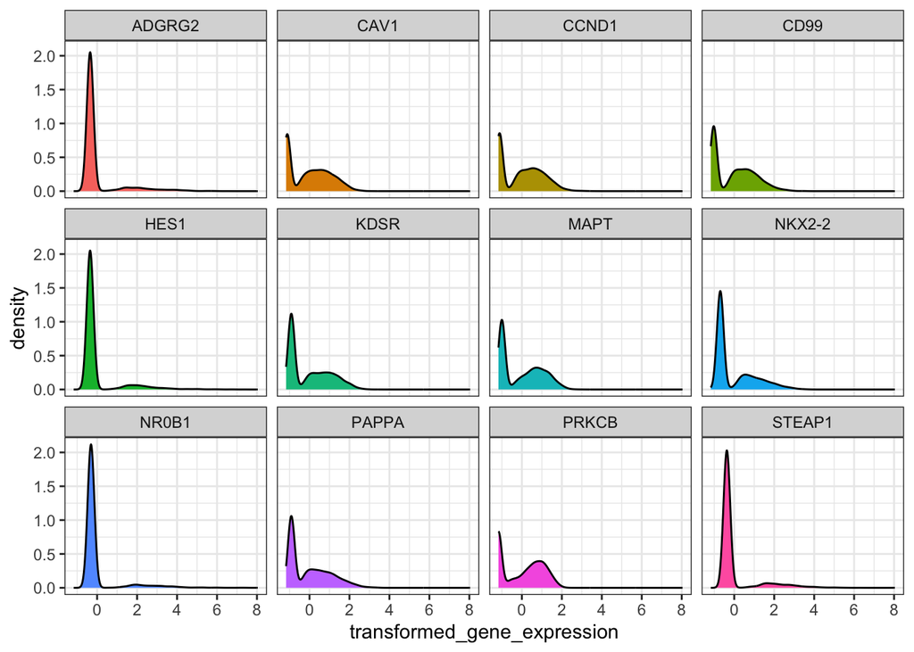

```r
ggplot(umap_df, aes(x = transformed_gene_expression, fill = gene_symbol)) +
  geom_density() +
  facet_wrap(vars(gene_symbol)) +
  theme(legend.position = "none")
```

It looks like some marker genes have distinct groups of cells with z-score > 0, while other marker genes may not be as informative. Keep in mind this could vary somewhat across patients, so I’m wary to remove marker genes without looking across multiple references.

### Classify tumor cells using marker genes only

Let’s try and use the marker gene expression to classify tumor cells. It looks like we could use a cutoff of z-score > 0 to count that cell as a tumor cell.

Below, we can get the sum of the transformed gene expression of all marker genes and plot in a single UMAP.

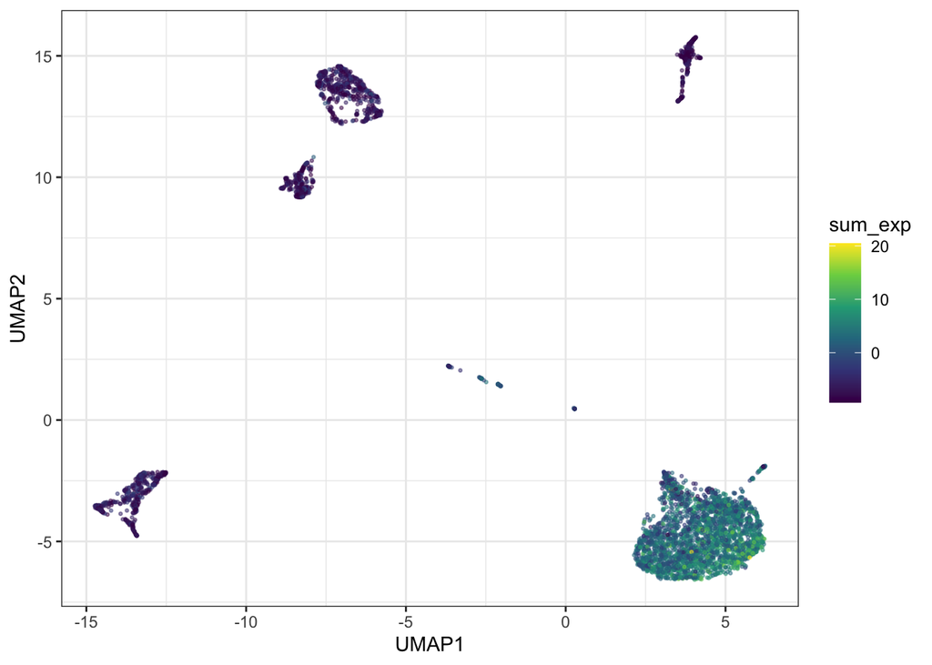

```r
# calculate sum gene expression across all marker genes in list
marker_sum_exp <- umap_df |>
  dplyr::group_by(barcodes) |>
  dplyr::mutate(sum_exp = sum(transformed_gene_expression)) |>
  dplyr::select(barcodes, UMAP1, UMAP2, sum_exp, cluster) |>
  dplyr::distinct()

# plot mean gene expression
ggplot(marker_sum_exp, aes(x = UMAP1, y = UMAP2, color = sum_exp)) +
  geom_point(size = 0.5, alpha = 0.5) +
  scale_color_viridis_c()
```

Similar to the individual plots, it looks like there is one group of cells on the bottom right that has the highest marker gene expression. We would anticipate that these are most likely to be the tumor cells.

Now let’s classify any cell that has a sum of marker genes > 0 (after z-transformation) as tumor cells.

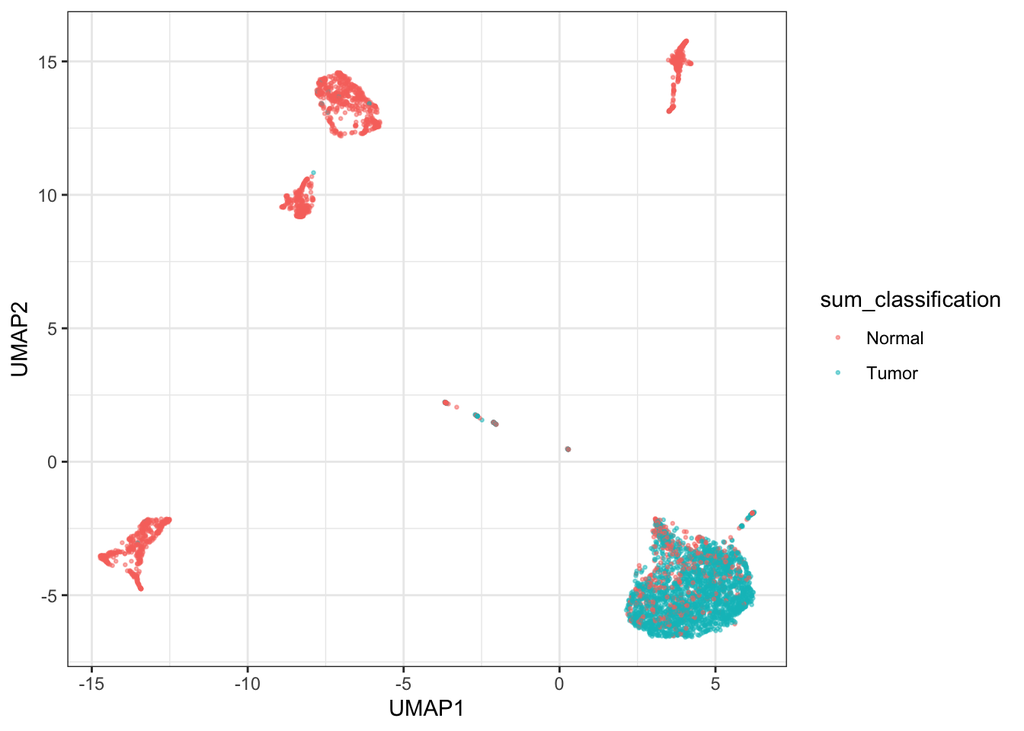

```r
# classify tumor cells based on presence of any marker genes
marker_sum_exp <- marker_sum_exp |>
  dplyr::mutate(sum_classification = dplyr::if_else(sum_exp > 0, "Tumor", "Normal"))

ggplot(marker_sum_exp, aes(x = UMAP1, y = UMAP2, color = sum_classification)) +
  geom_point(size = 0.5, alpha = 0.5)
```

This gives us a rough idea of cells that may be classified as tumor cells. Let’s look at the expression of each marker gene in tumor vs. normal cells and see if we see distinct separation between all of them or only a subset.

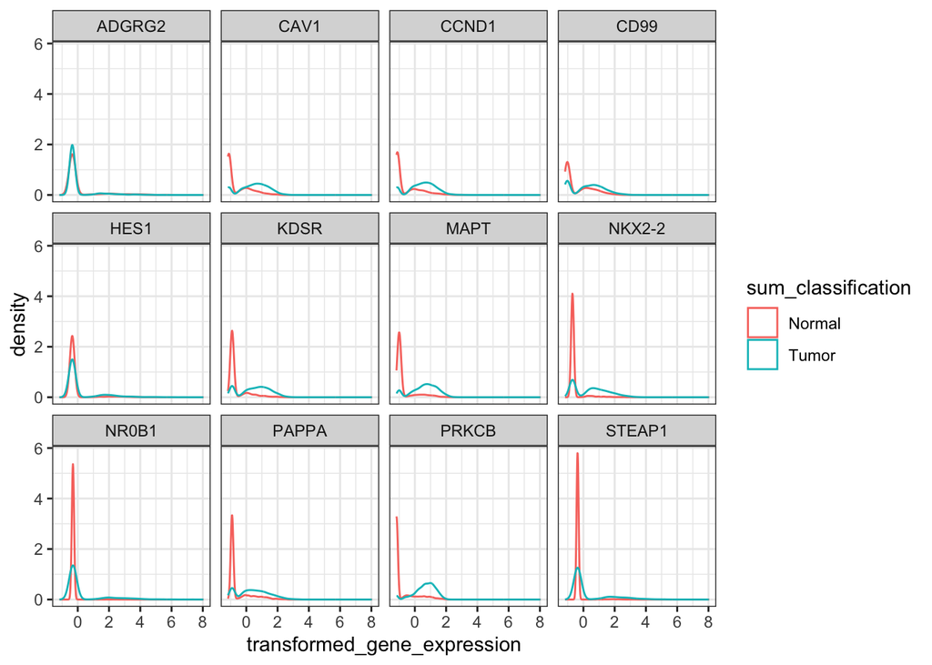

```r
# add cell types from sum classification to plotting df
celltype_df <- umap_df |>
  dplyr::left_join(marker_sum_exp)
# make plot with gene on y-axis, expression on x-axis and then color density by tumor/normal
# do all marker genes so differences between tumor/normal or only a subset?
ggplot(celltype_df, aes(x=transformed_gene_expression, color = sum_classification)) +
  geom_density() +
  facet_wrap(vars(gene_symbol))
```

It looks like `ADGRG2`, `HES1`, `NROB1`, and `STEAP1` don’t show a lot of difference between cells that might be tumor vs. normal cells and are generally lowly expressed. CD99 appears to be expressed in both normal and tumor at similar levels. All other genes show differences between the two, although at varying degrees. Again, we should make sure this is consistent across multiple patients before removing these genes as marker genes.

### Marker genes using `findMarkers`

Below, we will use `scran::findMarkers()` to find any markers between tumor and normal cells. Since we used marker genes to classify tumor cells, I would expect that at least some of the top markers would be from our list of tumor markers.

```r
# add in tumor/normal classification to colData of SCE
celltypes_only_df <- marker_sum_exp |>
  dplyr::select(barcodes, sum_classification)

coldata_df <- as.data.frame(colData(sce)) |>
  dplyr::left_join(celltypes_only_df)
colData(sce) <- DataFrame(coldata_df, row.names = rownames(coldata_df))

# find markers between tumor and normal
markers <- scran::findMarkers(sce,
                              groups = sce$sum_classification,
                              pval.type = "all")
```

```r
# pull out top markers for tumor cells
tumor_markers <- markers$Tumor |>
  as.data.frame() |>
  tibble::rownames_to_column("ensembl_gene_id") |>
  # join to get gene symbols to print out later
  dplyr::left_join(marker_genes_df) |>
  # just take those with FDR < 0.05 and logFC > 1.5
  dplyr::filter(FDR < 0.05, summary.logFC > 1.5) |>
  dplyr::arrange(FDR)
# get any marker genes that are in both findMarkers and our curated list
marker_gene_intersect <- tumor_markers |>
  dplyr::filter(cell_type == "tumor")

# print out genes that are marker genes for both
marker_gene_intersect
```

```
##   ensembl_gene_id p.value FDR summary.logFC logFC.Normal cell_type gene_symbol
## 1 ENSG00000166501       0   0      2.397842     2.397842     tumor       PRKCB
## 2 ENSG00000186868       0   0      1.648825     1.648825     tumor        MAPT
```

### Looking at marker genes across tumor cells

We would expect that cells we are labeling as tumor cells have expression of the tumor marker genes. Cells labeled as normal should not have expression of the markers.

Below we visualize the total number of cells that are classified as tumor or normal using the sum of marker gene expression. Then for each set of cells, how many of those actually express each marker gene.

We expect that good marker genes will be expressed in tumor cells but not normal cells.

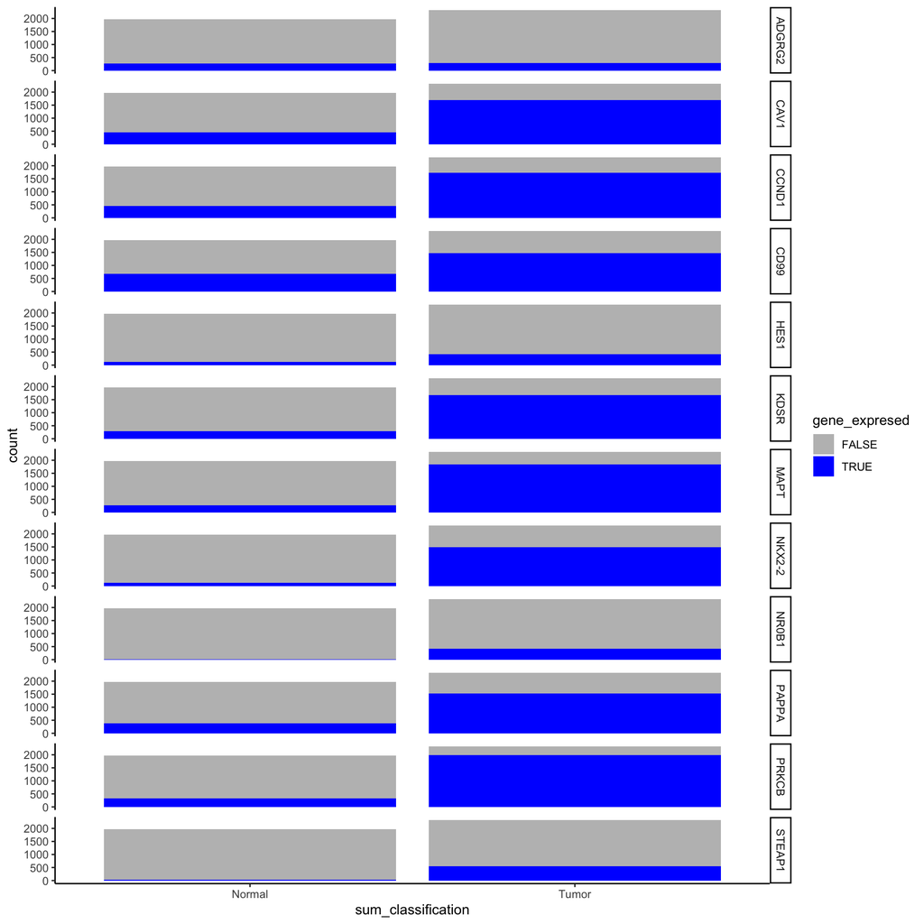

```r
marker_plot_df <- celltype_df |>
  dplyr::mutate(gene_expresed = dplyr::if_else(transformed_gene_expression > 0, TRUE, FALSE)) |>
  dplyr::select(gene_symbol, gene_expresed, sum_classification)

ggplot(marker_plot_df, aes(x = sum_classification, fill = gene_expresed)) +
  geom_bar(stat = "count") +
  facet_grid(rows = vars(gene_symbol)) +
  scale_fill_manual(values = c("grey", "blue")) +
  theme_classic()
```

Looking at this might help give us an idea of genes that are more specifically expressed in tumor cells. Genes like `ADGRG2` and `HES1` do not seem specific to tumor cells. There are normal and tumor cells that express the gene and not very many tumor cells actually have expression of `ADGRG2.` `STEAP1` and `NROB1` although not expressed in very many tumor cells, look to be specific to tumor cells which is promising.

`CD99`, `CAV1`, and `CCND1` are expressed in a high proportion of tumor cells but are also expressed in quite a few normal cells. This is consistent with the literature for `CD99` that it is expressed in normal cells, just at a lower level than in Ewing’s cells.

`KDSR`, `MAPT`, `NKX2-2`, `PAPPA`, and `PRKCB` all seem to have a high proportion of tumor cells expressing the gene and a low proportion of normal cells that express the gene. `PRKCB` and `MAPT` are also 2 of the top genes identified using the marker analysis.

Almost all genes have at least some expression in normal cells. Perhaps those cells should also be categorized as tumor cells, or they just have some baseline expression in normal cells which is possible.

### Compare with SingleR and CellAssign classifications

The last thing we will do here is compare our manual annotations with the annotations using `SingleR` and `CellAssign`. Looking at the annotations and UMAPs in the supplemental report, it looks like our group of “Tumor” cells are classified mostly as “Muscle cells” by both SingleR and CellAssign. This makes sense since Ewing’s sarcoma cells tend to resemble muscle cells.

I would expect the Endothelial cells, Fibroblasts, and Macrophages assigned by `CellAssign` and `SingleR` to line up with the normal cells in this sample.

Let’s create a heatmap looking at the Jaccard similarity index between each of the assigned cell types and the tumor/normal classification.

```r
# get all assigned cell types in one dataframe
celltypes_df <- as.data.frame(colData(sce)) |>
  dplyr::select(barcodes, singler_celltype_annotation, cellassign_celltype_annotation) |>
  dplyr::left_join(marker_sum_exp)
```

```r
celltype_columns <- c(
  "singler_celltype_annotation",
  "cellassign_celltype_annotation"
)

# create jaccard matrices for SingleR and CellAssign compared to tumor/normal
jaccard_matrices <- celltype_columns |>
  purrr::map(\(name) {
    make_jaccard_matrix(
      celltypes_df,
      "sum_classification",
      name
    )
  }) |>
  purrr::set_names("SingleR", "CellAssign")
```

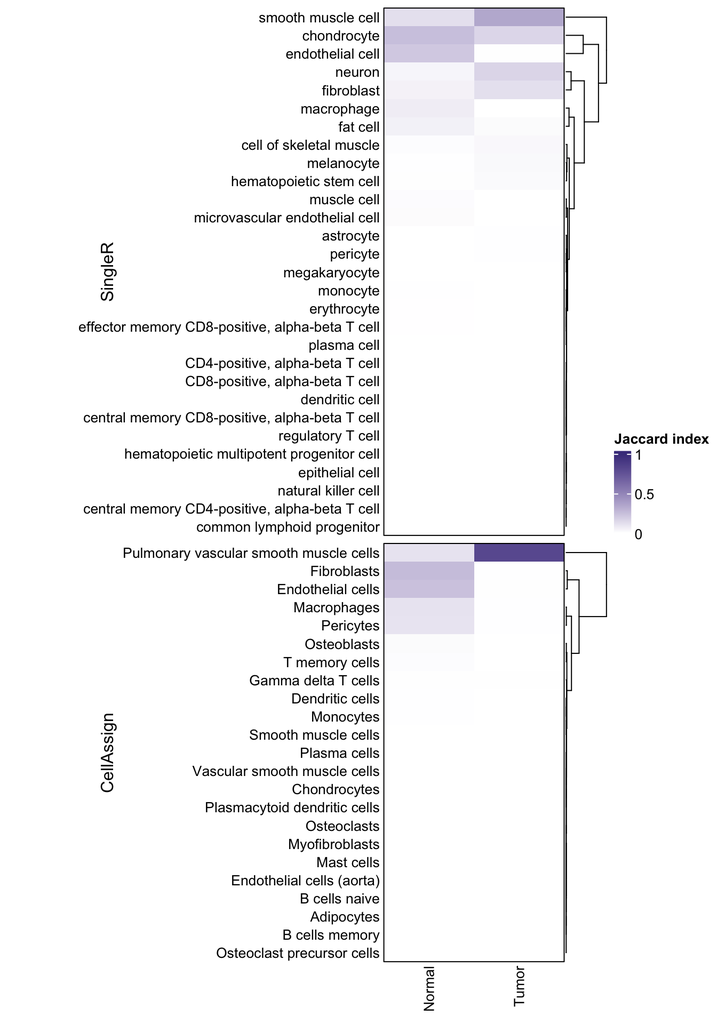

```r
# Set heatmap padding option
heatmap_padding <- 0.2
ComplexHeatmap::ht_opt(TITLE_PADDING = grid::unit(heatmap_padding, "in"))

# list of heatmaps looking at SingleR/ CellAssign vs tumor/normal
heatmap <- jaccard_matrices |>
  purrr::imap(
    \(celltype_mat, celltype_method) {
      ComplexHeatmap::Heatmap(
        t(celltype_mat), # transpose because matrix rows are in common & we want a vertical arrangement
        col = circlize::colorRamp2(c(0, 1), colors = c("white", "darkslateblue")),
        border = TRUE,
        ## Row parameters
        cluster_rows = TRUE,
        row_title = celltype_method,
        row_title_gp = grid::gpar(fontsize = 12),
        row_title_side = "left",
        row_names_side = "left",
        row_dend_side = "right",
        row_names_gp = grid::gpar(fontsize = 10),
        ## Column parameters
        cluster_columns = FALSE,
        column_title = "",
        column_title_gp = grid::gpar(fontsize = 12),
        column_names_side = "bottom",
        column_names_gp = grid::gpar(fontsize = 10),
        column_names_rot = 90,
        ## Legend parameters
        heatmap_legend_param = list(
          title = "Jaccard index",
          direction = "vertical",
          legend_width = unit(1.5, "in")
        ),
        show_heatmap_legend = celltype_method == "SingleR",
      )
    }) |>
  # concatenate vertically into HeatmapList object
  purrr::reduce(ComplexHeatmap::`%v%`) |>
  ComplexHeatmap::draw(
    heatmap_legend_side = "right",
    # add a margin to the heatmap so labels don't get cut off
    padding = unit(c(2, 20, 2, 2), "mm")
  )
```

When looking at `SingleR`, we see that the tumor cells line up with smooth muscle cells, chondrocytes, neurons, and fibroblasts. Ewing’s cells have a neuronal like phenotype and express high levels of ECM genes, which may explain the overlap with chondrocytes and fibroblasts. We do see that macrophages and endothelial cells tend to line up with the normal cells, which is expected.

For CellAssign, all tumor cells are pulmonary vascular smooth muscle cells. We also see that normal cells contain some smooth muscle cells, but mostly are fibroblasts and endothelial cells.

Looking at the heatmap in the supplemental report, the endothelial cells called by SingleR and CellAssign have a lot of overlap. Let’s look at expression of marker genes in these endothelial cells compared to cells that are categorized as smooth muscle cells.

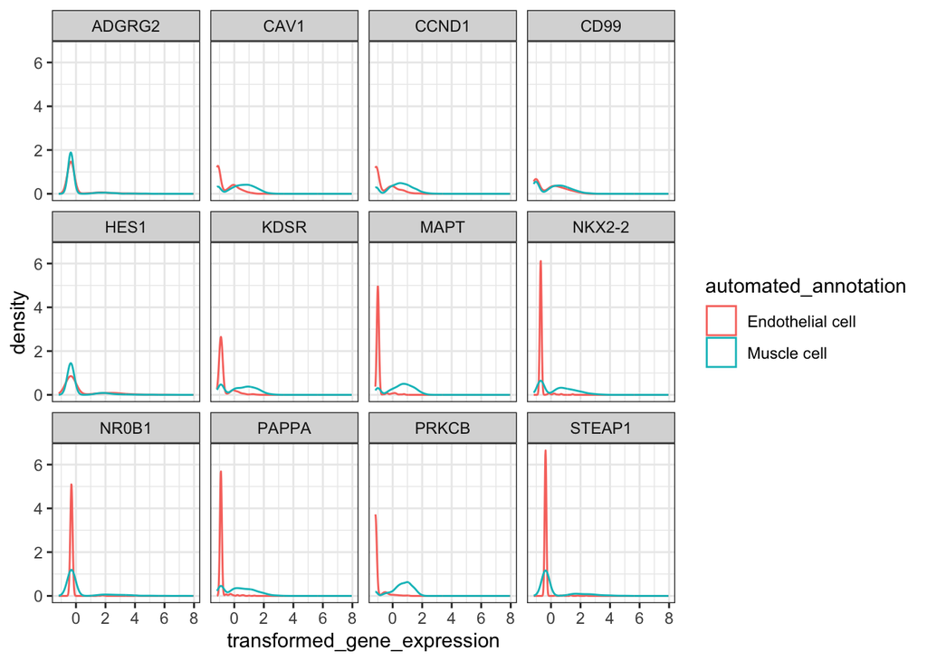

```r
select_celltype_df <- celltypes_df |>
  dplyr::mutate(
    automated_annotation = dplyr::case_when(
      singler_celltype_annotation == "smooth muscle cell" & cellassign_celltype_annotation == "Pulmonary vascular smooth muscle cells" ~ "Muscle cell",
      singler_celltype_annotation == "endothelial cell" & cellassign_celltype_annotation == "Endothelial cells" ~ "Endothelial cell"
    )
  ) |>
  dplyr::select(barcodes, automated_annotation)

annotation_plot_df <- umap_df |>
  dplyr::left_join(select_celltype_df) |>
  dplyr::filter(!is.na(automated_annotation))
ggplot(annotation_plot_df, aes(x = transformed_gene_expression, color = automated_annotation)) +
  geom_density() +
  facet_wrap(vars(gene_symbol))
```

## Conclusions

- We do see variation in marker gene expression across cells, suggesting that there are both tumor and normal cells here. - Using a z-score cut-off identifies a group of cells that appear to be tumor. .
- The top marker genes for the “tumor” cells contain PRKCB and MAPT, two of the marker genes in our gene list.
- It’s likely that `ADGRG2`, `HES1`, `NROB1`, and `STEAP1` will not be informative in assigning tumor cells.
- We may be weary of genes like `CD99` too as expression is more consistent across cells rather than specific to a group of cells.
- Endothelial cells as identified by SingleR and CellAssign generally have low expression of these marker genes and muscle cells have higher expression of marker genes.

## Save outputs

```r
# get a dataframe with barcodes, sum_classification and cluster_classification
celltypes_df <- celltypes_df |>
  dplyr::select(
    barcodes,
    marker_gene_classification = sum_classification
  )

readr::write_tsv(celltypes_df, output_classifications_file)
```